# Mako hSDM BRT explore (ROMS and CMEM domains)

Author

Emily Nazario

Published

February 8, 2024

On this document I start my initial exploration with the different model outputs, ranking of covariate influence, and projections. Here, I only explore BRT approaches, but later I may also explore and compare those from GAMMs. The hypotheses I would like to test with these models are as follows:

**H1:** The aerobic growth index (AGI) at deeper depths will have a larger relative influence on habitat suitability than the AGI values closer to the surface.

*study objective being met:* Understand how the AGI across depth layers influences habitat suitability. Are AGI values at deeper depths more influential? This would make sense given the reductions in oxygen availability and would be interesting given anticipated changes for the shoaling OMZ.

**H2:** The AGI will have important pairwise interactions with latitude and longitude.

*study objective being met:* Understand how the AGI moving towards the equator (theoretical thermal and metabolic edge for makos) and towards the coast (more shallow OMZs) may influence habitat suitability. Coastal areas in Baja are expected to be the regions that would be the first to become metabolically challenging under prediceted climate change scenarios.

**H3:** Models with the AGI as a covariate will have better predictive power than models with just dissolved oxygen and temperature.

*study objective being met:* Here, I am interested in understanding how model performance differs when AGI is a covariate relative to when DO and temperature are covariates. This will be an interesting feature to see what this physio-informed metric brings to the table for this study. Will it be informative? Or will the unique metabolic demands of mako sharks be underrepresented in this metric?

# CMEM Surface BRT w/ AGI at 0m and 250m (all covar included except DO and Temp at those depths)

Below are the model outputs for a BRT developed with all covariates values extracted at 0m and 250m depth except for DO and Temperature. By doing this I hoped to isolate the effect that the AGI has on model predictive power that I can then compare to the other models on this document (1) a BRT without AGI and DO and temperature, and (2) a BRT with AGI and temperature (not DO).

## AGI tc5, lr0.01, bf0.75

```r
# try(agi_tc5_lr01 <- dismo::gbm.step(data = dat_train,
#                                     gbm.x = c(4, 9:10, 12:14, 16:17, 19:20),
#                                     gbm.y = 5,
#                                     family = "bernoulli",
#                                     tree.complexity = 5,
#                                     learning.rate = 0.01,
#                                     bag.fraction = 0.75,
#                                     silent = TRUE,
#                                     plot.main = TRUE))

#saveRDS(agi_tc5_lr01, here("data/brt/mod_bls/agi_tc5_lr01.rds"))

  #load model so I don't run every time
agi_tc5_lr01 <- readRDS(here("data/brt/mod_bls/agi_tc5_lr01.rds"))

ggBRT::ggPerformance(agi_tc5_lr01)
```

```
                     Model 1
Total.Deviance     1.3862201
Residual.Deviance  0.2259500
Correlation        0.9600801
AUC                0.9991000
Per.Expl          83.7002822
cvDeviance         0.5910143
cvCorrelation      0.7989438
cvAUC              0.9447100
cvPer.Expl        57.3650441
```

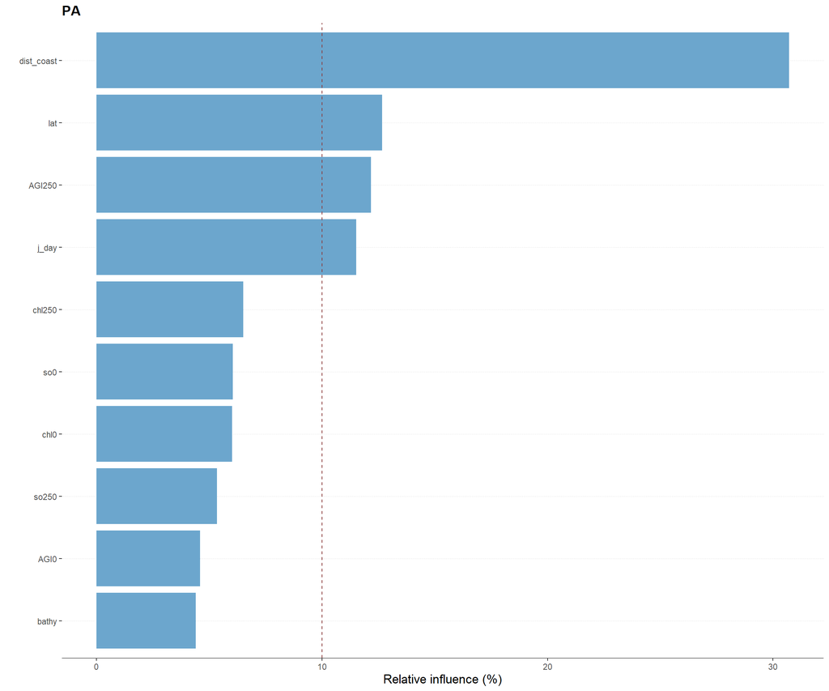

```
             rel.inf
dist_coast 30.705893
lat        12.664069
AGI250     12.168610
j_day      11.524357
chl250      6.515390
so0         6.045857
chl0        6.023929
so250       5.342350
AGI0        4.598433
bathy       4.411113
```

```r
#relative influence of predictors
ggBRT::ggInfluence(agi_tc5_lr01)
```

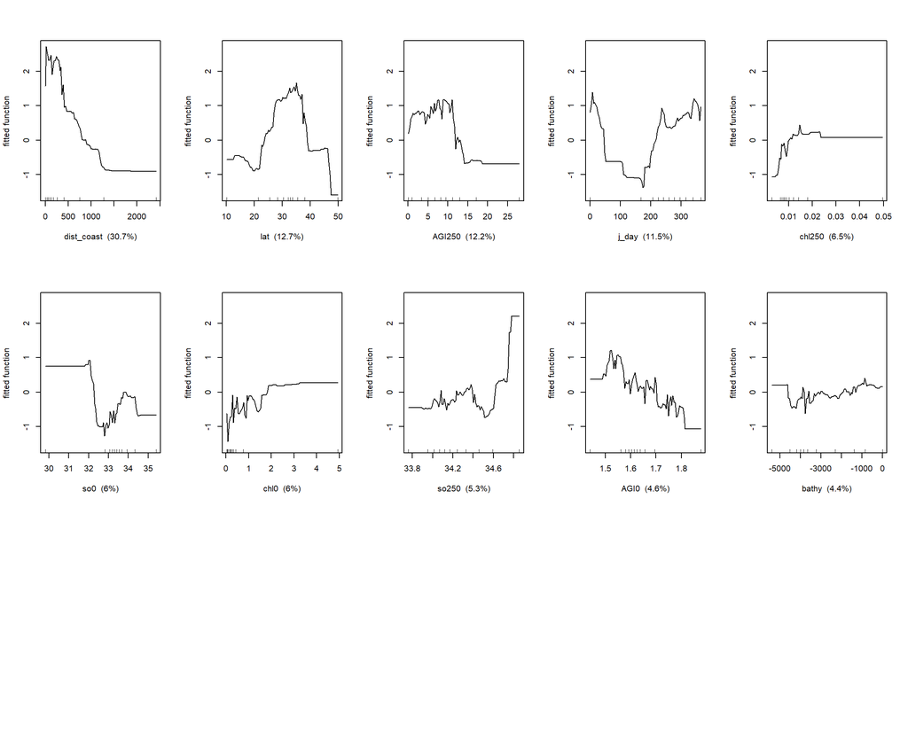

```r
#explore partial plots
gbm.plot(agi_tc5_lr01, nplots = 10, plot.layout = c(3,5), write.title = FALSE)
```

```r
#find the 5 most important pairwise interactions
AGI_int <- gbm.interactions(agi_tc5_lr01)
AGI_int$rank.list
```

```
  var1.index var1.names var2.index var2.names int.size
1          5       AGI0          1        lat   555.37
2         10      j_day          1        lat   513.00
3          8     chl250          5       AGI0   217.13
4         10      j_day          7      so250   192.64
5          9     AGI250          7      so250   181.49
```

```r
#predictions
preds <- predict.gbm(agi_tc5_lr01, dat_test,
                     n.trees = agi_tc5_lr01$gbm.call$best.trees,
                     type = "response")

calc.deviance(obs = dat_test$PA, preds)
```

```
[1] 0.3278299
```

```r
dat_pred <- cbind(dat_test$PA, preds)
pres <- dat_pred[dat_pred[,1] == 1, 2]
abs <- dat_pred[dat_pred[,1] == 0, 2]

evaluate(p = pres, a = abs)
```

```
class          : ModelEvaluation
n presences    : 934
n absences     : 922
AUC            : 0.9880143
cor            : 0.9156653
max TPR+TNR at : 0.4891491
```

## HSI map

**2004**

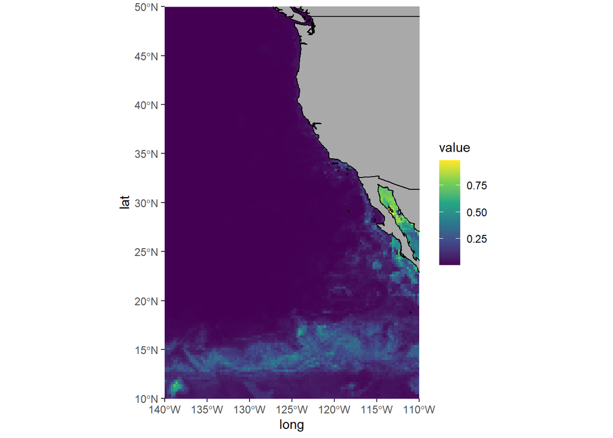

```r
   #make HSI plot
agi_rast_2004 <- rast(here("data/enviro/CMEMS/hsi_map/agi_covar2004_spatrast.nc"))
names(agi_rast_2004) <- c("so0", "chl0","so250", "chl250", "bathy", "dist_coast", "AGI0", "AGI250", "lat", "j_day")

map_pred = predict(agi_rast_2004, agi_tc5_lr01, type = "response", n.trees = agi_tc5_lr01$gbm.call$best.trees, na.rm = FALSE)
extent1<-c(-140,-110,10,50)
map_pred = crop(map_pred,extent1)

df_map = as.points(map_pred) %>% st_as_sf() %>% as.data.frame()
colnames(df_map) = c("value", "geometry")

map.world = map_data(map="world")
testt=map.world %>% filter(long<=180)

ggplot() +
  geom_spatraster(data = map_pred) +
  geom_map(data=testt,map=testt,aes(map_id=region,x=long,y=lat),fill="darkgrey",color="black")+
  scale_x_continuous(expand=c(0,0),limits = c(-140,-110)) +
    scale_y_continuous(expand=c(0,0),limits = c(10,50))+
  scale_fill_viridis_c()
```

**2007**

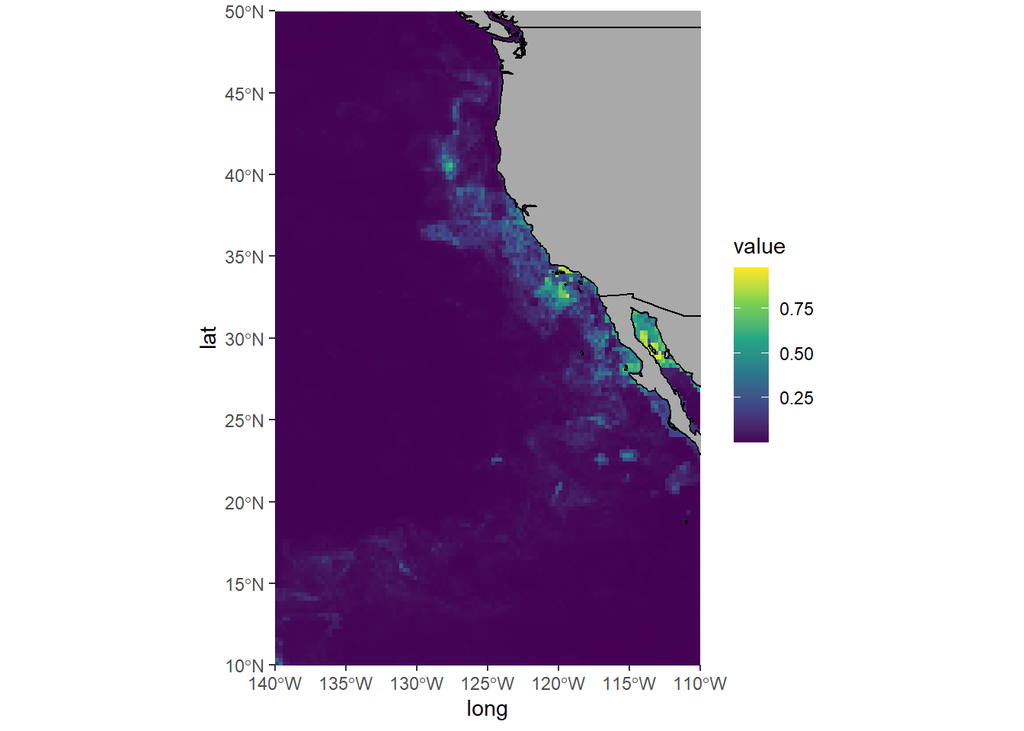

```r
   #make HSI plot
agi_rast_2007 <- rast(here("data/enviro/CMEMS/hsi_map/agi_covar2007_spatrast.nc"))
names(agi_rast_2007) <- c("so0", "chl0","so250", "chl250", "bathy", "dist_coast", "AGI0", "AGI250", "lat", "j_day")

map_pred = predict(agi_rast_2007, agi_tc5_lr01, type = "response", n.trees = agi_tc5_lr01$gbm.call$best.trees, na.rm = FALSE)
map_pred = crop(map_pred,extent1)

df_map = as.points(map_pred) %>% st_as_sf() %>% as.data.frame()
colnames(df_map) = c("value", "geometry")

map.world = map_data(map="world")
testt=map.world %>% filter(long<=180)

ggplot() +
  geom_spatraster(data = map_pred) +
  geom_map(data=testt,map=testt,aes(map_id=region,x=long,y=lat),fill="darkgrey",color="black")+
  scale_x_continuous(expand=c(0,0),limits = c(-140,-110)) +
    scale_y_continuous(expand=c(0,0),limits = c(10,50))+
  scale_fill_viridis_c()
```

**2009**

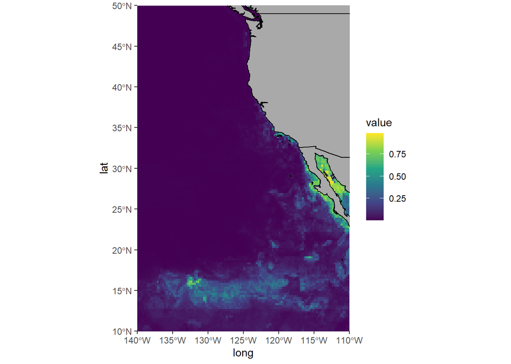

```r
   #make HSI plot
agi_rast_2009 <- rast(here("data/enviro/CMEMS/hsi_map/agi_covar2009_spatrast.nc"))
names(agi_rast_2009) <- c("so0", "chl0","so250", "chl250", "bathy", "dist_coast", "AGI0", "AGI250", "lat", "j_day")

map_pred = predict(agi_rast_2009, agi_tc5_lr01, type = "response", n.trees = agi_tc5_lr01$gbm.call$best.trees, na.rm = FALSE)
map_pred = crop(map_pred,extent1)

df_map = as.points(map_pred) %>% st_as_sf() %>% as.data.frame()
colnames(df_map) = c("value", "geometry")

map.world = map_data(map="world")
testt=map.world %>% filter(long<=180)

ggplot() +
  geom_spatraster(data = map_pred) +
  geom_map(data=testt,map=testt,aes(map_id=region,x=long,y=lat),fill="darkgrey",color="black")+
  scale_x_continuous(expand=c(0,0),limits = c(-140,-110)) +
    scale_y_continuous(expand=c(0,0),limits = c(10,50))+
  scale_fill_viridis_c()
```

# CMEM model w/ DO and Temp. at 0m and 250m depth. Plus all covar except AGI at those depths.

Here is the model without AGI and just DO and temperature values at 0m and 250m depth for all positions.

## DO/temp tc5, lr0.01, bf0.75

```r
#fit the model
# try(do_tc5_lr01 <- dismo::gbm.step(data = dat_train,
#                                     gbm.x = c(4, 8:12, 14:18, 20),
#                                     gbm.y = 5,
#                                     family = "bernoulli",
#                                     tree.complexity = 5,
#                                     learning.rate = 0.01,
#                                     bag.fraction = 0.75,
#                                     silent = TRUE,
#                                     plot.main = TRUE))

#saveRDS(do_tc5_lr01, here("data/brt/mod_bls/do_temp_tc5_lr01.rds"))

 #load model so I don't run every time
do_tc5_lr01 <- readRDS(here("data/brt/mod_bls/do_temp_tc5_lr01.rds"))

ggBRT::ggPerformance(do_tc5_lr01)
```

```
                     Model 1
Total.Deviance     1.3862201
Residual.Deviance  0.2069805
Correlation        0.9650525
AUC                0.9993000
Per.Expl          85.0687147
cvDeviance         0.5719114
cvCorrelation      0.8083554
cvAUC              0.9478800
cvPer.Expl        58.7431040
```

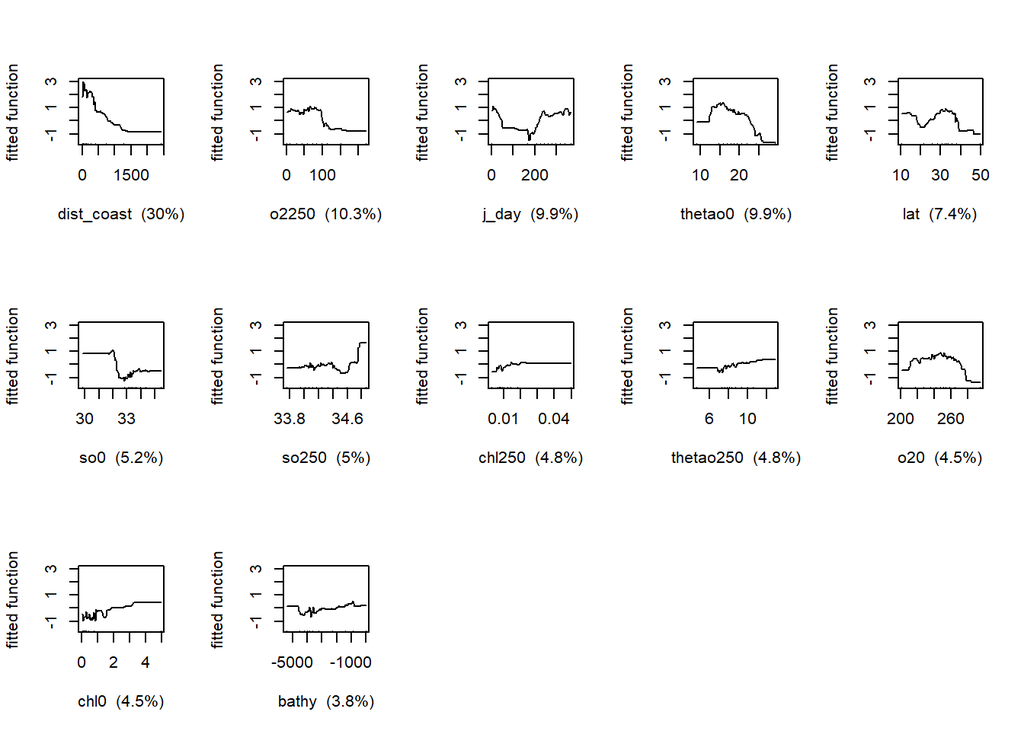

```r
#explore outputs
gbm.plot(do_tc5_lr01, nplots = 15, plot.layout = c(3,5), write.title = FALSE)
```

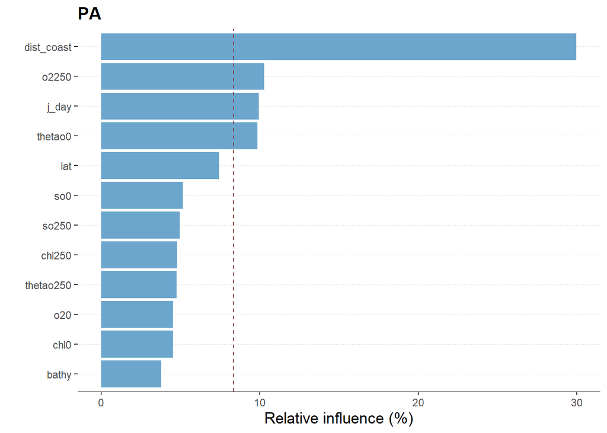

```
             rel.inf
dist_coast 29.989137
o2250      10.286133
j_day       9.934911
thetao0     9.861438
lat         7.447473
so0         5.163593
so250       4.958164
chl250      4.781817
thetao250   4.758306
o20         4.525617
chl0        4.513247
bathy       3.780165
```

```r
#relative influence of predictors
ggBRT::ggInfluence(do_tc5_lr01)
```

```r
#find the 5 most important pairwise interactions
do_int <- gbm.interactions(do_tc5_lr01)
do_int$rank.list
```

```
  var1.index var1.names var2.index var2.names int.size
1          5        o20          3        so0   394.67
2         12      j_day          8  thetao250   284.38
3          5        o20          1        lat   197.08
4          9      so250          8  thetao250   170.82
5         11      o2250          9      so250   158.86
6          3        so0          2    thetao0   137.66
7          8  thetao250          3        so0   128.37
```

```r
#predictions
preds <- predict.gbm(do_tc5_lr01, dat_test,
                     n.trees = do_tc5_lr01$gbm.call$best.trees,
                     type = "response")

calc.deviance(obs = dat_test$PA, preds)
```

```
[1] 0.3076983
```

```r
dat_pred <- cbind(dat_test$PA, preds)
pres <- dat_pred[dat_pred[,1] == 1, 2]
abs <- dat_pred[dat_pred[,1] == 0, 2]

evaluate(p = pres, a = abs)
```

```
class          : ModelEvaluation
n presences    : 934
n absences     : 922
AUC            : 0.9893148
cor            : 0.9209534
max TPR+TNR at : 0.5759268
```

## HSI map

**2004**

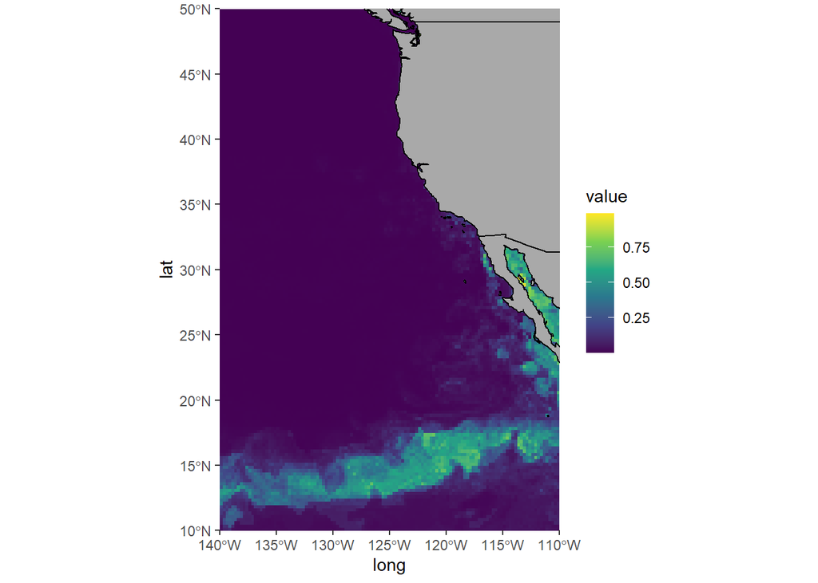

```r
   #make HSI plot
do_rast_2004 <- rast(here("data/enviro/CMEMS/hsi_map/do_covar2004_spatrast.nc"))
names(do_rast_2004) <- c("thetao0", "so0", "chl0", "o20", "thetao250", "so250", "chl250", "o2250", "bathy", "dist_coast", "lat", "j_day")

map_pred = predict(do_rast_2004, do_tc5_lr01, type = "response", n.trees = do_tc5_lr01$gbm.call$best.trees, na.rm = FALSE)
map_pred = crop(map_pred,extent1)

df_map = as.points(map_pred) %>% st_as_sf() %>% as.data.frame()
colnames(df_map) = c("value", "geometry")

map.world = map_data(map="world")
testt=map.world %>% filter(long<=180)

ggplot() +
  geom_spatraster(data = map_pred) +
  geom_map(data=testt,map=testt,aes(map_id=region,x=long,y=lat),fill="darkgrey",color="black")+
  scale_x_continuous(expand=c(0,0),limits = c(-140,-110)) +
    scale_y_continuous(expand=c(0,0),limits = c(10,50))+
  scale_fill_viridis_c()
```

**2007**

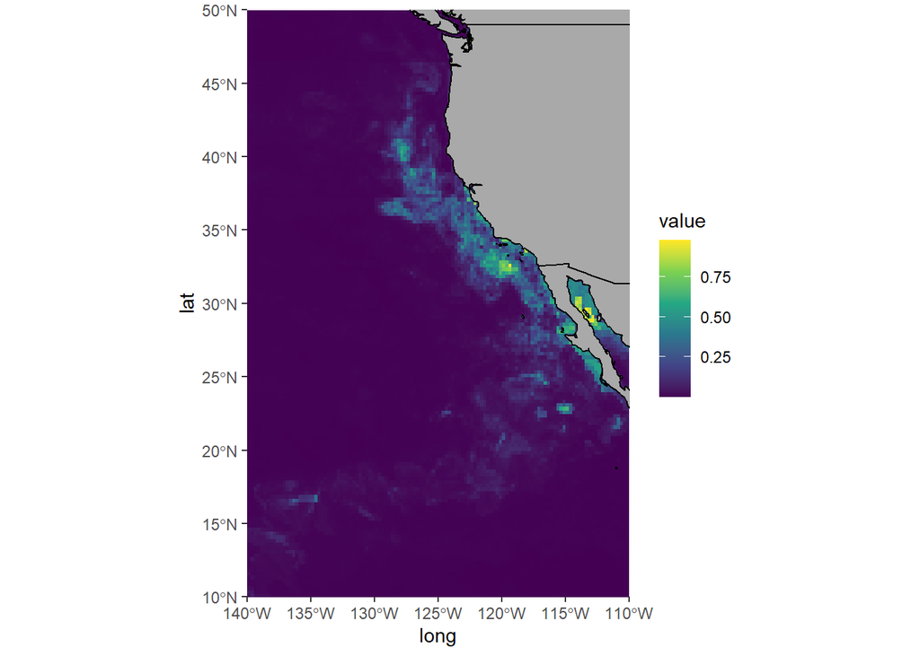

```r
   #make HSI plot
do_rast_2007 <- rast(here("data/enviro/CMEMS/hsi_map/do_covar2007_spatrast.nc"))
names(do_rast_2007) <- c("thetao0", "so0", "chl0", "o20", "thetao250", "so250", "chl250", "o2250", "bathy", "dist_coast", "lat", "j_day")

map_pred = predict(do_rast_2007, do_tc5_lr01, type = "response", n.trees = do_tc5_lr01$gbm.call$best.trees, na.rm = FALSE)
map_pred = crop(map_pred,extent1)

df_map = as.points(map_pred) %>% st_as_sf() %>% as.data.frame()
colnames(df_map) = c("value", "geometry")

map.world = map_data(map="world")
testt=map.world %>% filter(long<=180)

ggplot() +
  geom_spatraster(data = map_pred) +
  geom_map(data=testt,map=testt,aes(map_id=region,x=long,y=lat),fill="darkgrey",color="black")+
  scale_x_continuous(expand=c(0,0),limits = c(-140,-110)) +
    scale_y_continuous(expand=c(0,0),limits = c(10,50))+
  scale_fill_viridis_c()
```

**2009**

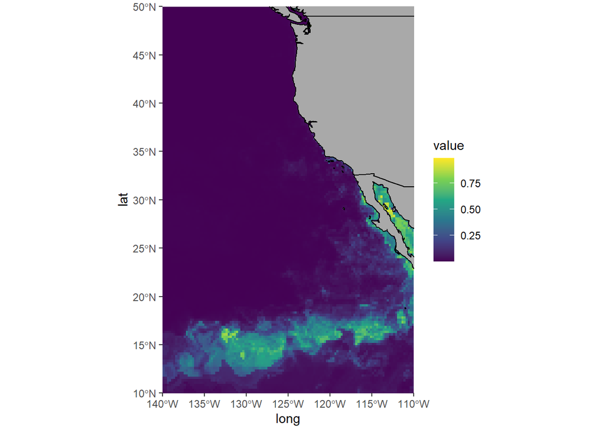

```r
   #make HSI plot
do_rast_2009 <- rast(here("data/enviro/CMEMS/hsi_map/do_covar2009_spatrast.nc"))
names(do_rast_2009) <- c("thetao0", "so0", "chl0", "o20", "thetao250", "so250", "chl250", "o2250", "bathy", "dist_coast", "lat", "j_day")

map_pred = predict(do_rast_2009, do_tc5_lr01, type = "response", n.trees = do_tc5_lr01$gbm.call$best.trees, na.rm = FALSE)
map_pred = crop(map_pred,extent1)

df_map = as.points(map_pred) %>% st_as_sf() %>% as.data.frame()
colnames(df_map) = c("value", "geometry")

map.world = map_data(map="world")
testt=map.world %>% filter(long<=180)

ggplot() +
  geom_spatraster(data = map_pred) +
  geom_map(data=testt,map=testt,aes(map_id=region,x=long,y=lat),fill="darkgrey",color="black")+
  scale_x_continuous(expand=c(0,0),limits = c(-140,-110)) +
    scale_y_continuous(expand=c(0,0),limits = c(10,50))+
  scale_fill_viridis_c()
```

# CMEM model w/ AGI and Temp. at 0m and 250m depth. Plus all covar except DO at those depths.

Here is the BRT with AGI and temp, and not DO. Here, I was interested in still including temperature because of all of the effects it has independent of its influence on the metabolic rate which is being captured by the AGI. Such influence includes temperature affects on prey species and temperature effects on the mako sharks physiology.

## AGI/temp tc5, lr0.01, bf0.75

```r
#fit the model
# try(agi_temp_tc5_lr01 <- dismo::gbm.step(data = dat_train,
#                                     gbm.x = c(4, 8:10, 12:17, 19:20),
#                                     gbm.y = 5,
#                                     family = "bernoulli",
#                                     tree.complexity = 5,
#                                     learning.rate = 0.01,
#                                     bag.fraction = 0.75,
#                                     silent = TRUE,
#                                     plot.main = TRUE))

#saveRDS(agi_temp_tc5_lr01, here("data/brt/mod_bls/agi_temp_tc5_lr01.rds"))

 #load model so I don't run every time
agi_temp_tc5_lr01 <- readRDS(here("data/brt/mod_bls/agi_temp_tc5_lr01.rds"))

ggBRT::ggPerformance(agi_temp_tc5_lr01)
```

```
                     Model 1
Total.Deviance     1.3862201
Residual.Deviance  0.2105598
Correlation        0.9644062
AUC                0.9993000
Per.Expl          84.8105057
cvDeviance         0.5779385
cvCorrelation      0.8059787
cvAUC              0.9470400
cvPer.Expl        58.3083142
```

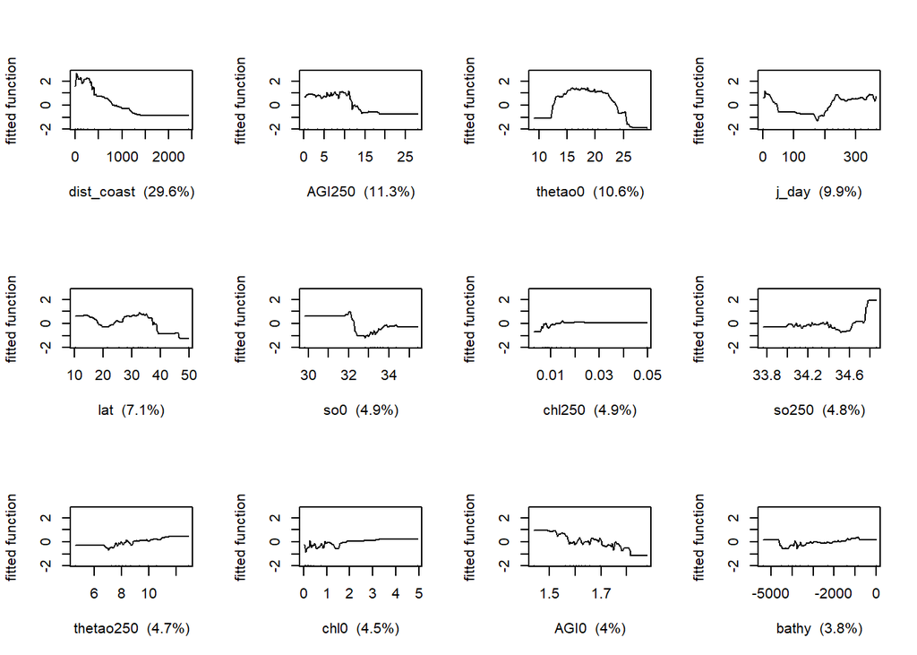

```r
#explore outputs
gbm.plot(agi_temp_tc5_lr01, nplots = 15, plot.layout = c(3,4), write.title = FALSE)
```

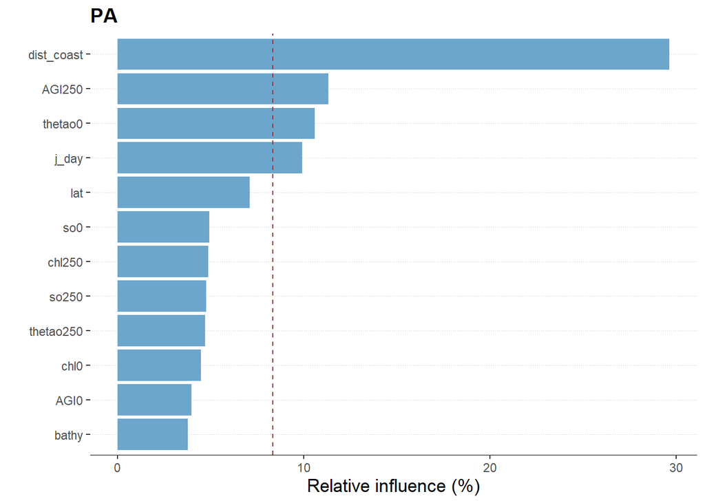

```
             rel.inf
dist_coast 29.634989
AGI250     11.323506
thetao0    10.581397
j_day       9.920532
lat         7.087342
so0         4.924414
chl250      4.880498
so250       4.755566
thetao250   4.690276
chl0        4.476186
AGI0        3.966073
bathy       3.759221
```

```r
#relative influence of predictors
ggBRT::ggInfluence(agi_temp_tc5_lr01)
```

```r
#find the 5 most important pairwise interactions
do_int <- gbm.interactions(agi_temp_tc5_lr01)
do_int$rank.list
```

```
  var1.index var1.names var2.index var2.names int.size
1          3        so0          2    thetao0   251.27
2         12      j_day          8  thetao250   230.04
3         12      j_day          1        lat   194.82
4          6       AGI0          1        lat   139.64
5          8  thetao250          3        so0   136.97
6         11     AGI250          9      so250   119.53
7         12      j_day          9      so250   112.17
```

```r
#predictions
preds <- predict.gbm(agi_temp_tc5_lr01, dat_test,
                     n.trees = agi_temp_tc5_lr01$gbm.call$best.trees,
                     type = "response")

calc.deviance(obs = dat_test$PA, preds)
```

```
[1] 0.312218
```

```r
dat_pred <- cbind(dat_test$PA, preds)
pres <- dat_pred[dat_pred[,1] == 1, 2]
abs <- dat_pred[dat_pred[,1] == 0, 2]

evaluate(p = pres, a = abs)
```

```
class          : ModelEvaluation
n presences    : 934
n absences     : 922
AUC            : 0.9890605
cor            : 0.920059
max TPR+TNR at : 0.571205
```

## HSI map

**2004**

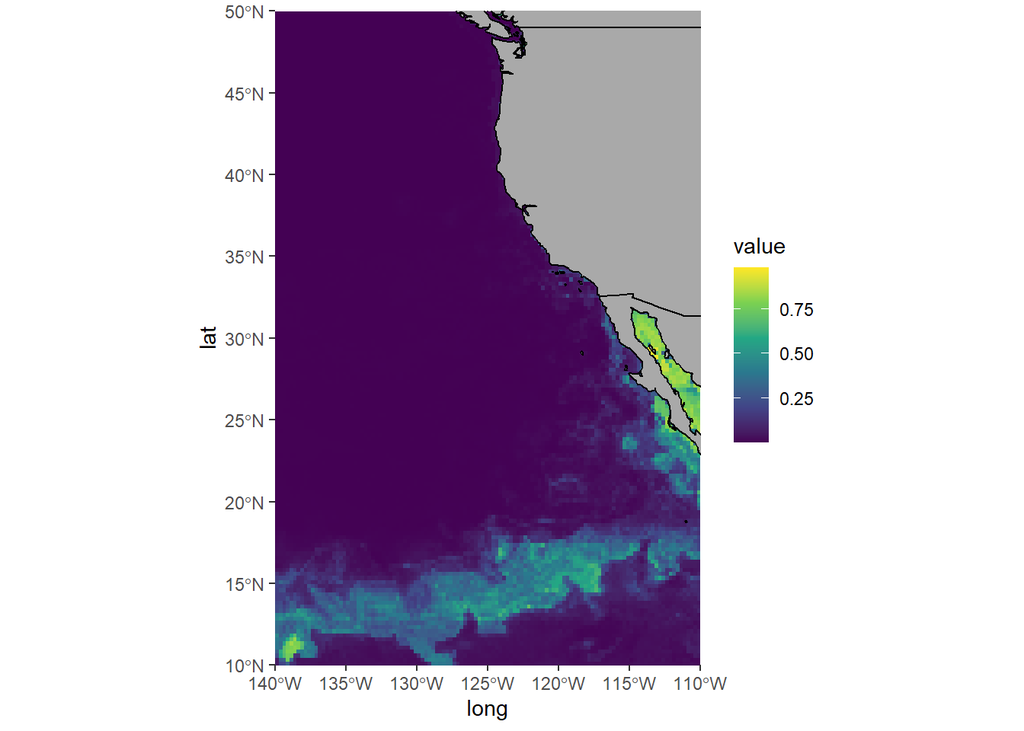

```r
   #make HSI plot
agi_temp_rast_2004 <- rast(here("data/enviro/CMEMS/hsi_map/agi_temp_covar2004_spatrast.nc"))
names(agi_temp_rast_2004) <- c("thetao0", "so0", "chl0", "thetao250", "so250", "chl250", "bathy", "dist_coast", "AGI0", "AGI250", "lat", "j_day")

map_pred = predict(agi_temp_rast_2004, agi_temp_tc5_lr01, type = "response", n.trees = agi_temp_tc5_lr01$gbm.call$best.trees, na.rm = FALSE)
map_pred = crop(map_pred,extent1)

df_map = as.points(map_pred) %>% st_as_sf() %>% as.data.frame()
colnames(df_map) = c("value", "geometry")

map.world = map_data(map="world")
testt=map.world %>% filter(long<=180)

ggplot() +
  geom_spatraster(data = map_pred) +
  geom_map(data=testt,map=testt,aes(map_id=region,x=long,y=lat),fill="darkgrey",color="black")+
  scale_x_continuous(expand=c(0,0),limits = c(-140,-110)) +
    scale_y_continuous(expand=c(0,0),limits = c(10,50))+
  scale_fill_viridis_c()
```

**2007**

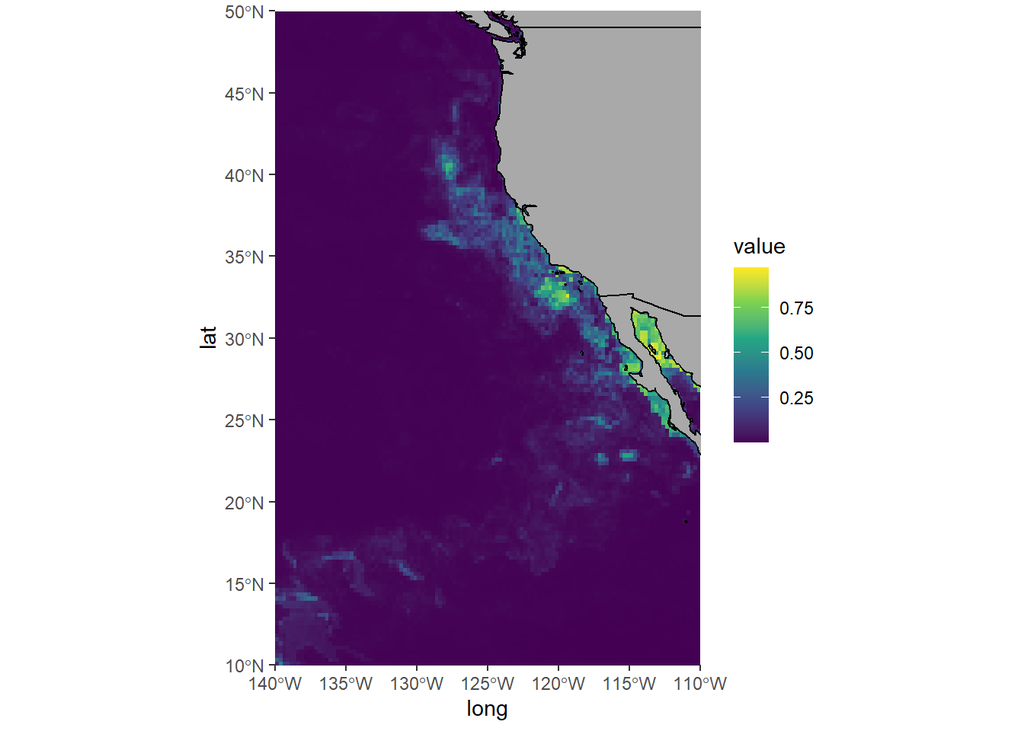

```r
   #make HSI plot
agi_temp_rast_2007 <- rast(here("data/enviro/CMEMS/hsi_map/agi_temp_covar2007_spatrast.nc"))
names(agi_temp_rast_2007) <- c("thetao0", "so0", "chl0", "thetao250", "so250", "chl250", "bathy", "dist_coast", "AGI0", "AGI250", "lat", "j_day")

map_pred = predict(agi_temp_rast_2007, agi_temp_tc5_lr01, type = "response", n.trees = agi_temp_tc5_lr01$gbm.call$best.trees, na.rm = FALSE)
map_pred = crop(map_pred,extent1)

df_map = as.points(map_pred) %>% st_as_sf() %>% as.data.frame()
colnames(df_map) = c("value", "geometry")

map.world = map_data(map="world")
testt=map.world %>% filter(long<=180)

ggplot() +
  geom_spatraster(data = map_pred) +
  geom_map(data=testt,map=testt,aes(map_id=region,x=long,y=lat),fill="darkgrey",color="black")+
  scale_x_continuous(expand=c(0,0),limits = c(-140,-110)) +
    scale_y_continuous(expand=c(0,0),limits = c(10,50))+
  scale_fill_viridis_c()
```

**2009**

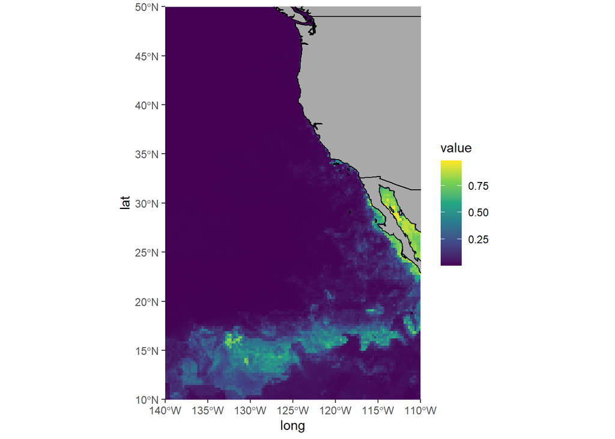

```r
   #make HSI plot
agi_temp_rast_2009 <- rast(here("data/enviro/CMEMS/hsi_map/agi_temp_covar2009_spatrast.nc"))
names(agi_temp_rast_2009) <- c("thetao0", "so0", "chl0", "thetao250", "so250", "chl250", "bathy", "dist_coast", "AGI0", "AGI250", "lat", "j_day")

map_pred = predict(agi_temp_rast_2009, agi_temp_tc5_lr01, type = "response", n.trees = agi_temp_tc5_lr01$gbm.call$best.trees, na.rm = FALSE)
map_pred = crop(map_pred,extent1)

df_map = as.points(map_pred) %>% st_as_sf() %>% as.data.frame()
colnames(df_map) = c("value", "geometry")

map.world = map_data(map="world")
testt=map.world %>% filter(long<=180)

ggplot() +
  geom_spatraster(data = map_pred) +
  geom_map(data=testt,map=testt,aes(map_id=region,x=long,y=lat),fill="darkgrey",color="black")+
  scale_x_continuous(expand=c(0,0),limits = c(-140,-110)) +
    scale_y_continuous(expand=c(0,0),limits = c(10,50))+
  scale_fill_viridis_c()
```